# Using litsearchr and synthesisr

Tania L.G. Maxwell

13/01/2023

This document tracks the literature search used to acquire the global database of soil carbon in tidal salt marshes. We are not yet distinguishing between carbon stocks and sequestration rates; we will determine based on the data whether we can model global C sequestration rates.

First, we will do a naive search with our initial Boolean keyword search, and then use the `litsearchr` package to include more terms representative of the literature. This workflow is based from the paper Grames et al. (2019), and from the online tutorial: https://luketudge.github.io/litsearchr-tutorial/litsearchr_tutorial.html#Getting_potential_search_terms

Once the final references have been extracted, we will use the `synthesisr` package

# Using litsearchr

## Setup

```r
library(remotes)
library(dplyr)
library(tidyr)
library(ggplot2)
library(ggraph)
library(igraph)
library(readr)
```

## Naive search

```r
#download github repro
#install_github("elizagrames/litsearchr", ref="main")
library(litsearchr)
```

First step is the naive search for studies with soil carbon data in tidal marshes or salt marshes.

Guidelines for writing a naive search (from Grames et al. 2019 S1)

*1. Identify your research question:*

What are the soil carbon stocks and carbon sequestration rates in tidal (salt) marshes at the global scale?

*2. Identify your concept groups (population more broadly as the study system, intervention as the predictor variables, and outcome as the response variables):*

Population/study system = tidal (salt) marshes

Intervention/predictor variables = what we are looking for

Outcome = soil carbon stocks and/or sequestration rates

*3. Use your prior knowledge, or consult with colleagues or experts in your field to generate an initial list of search terms that fit in your concept groups.*

We are interested in soil carbon, but we should include both inorganic and organic carbon, as well as specify if we want soil carbon stocks or sequestration.

*4. Combine your concept groups into a search string.*

```
      (("soil C" OR "soil carbon" OR "soil inorganic carbon" OR "soil organic carbon") OR
      ("soil carbon sequestrat*" OR "soil carbon stabiliz*" OR "soil carbon stock*"))

      AND ("tidal marsh*" OR "salt marsh*" OR saltmarsh*)
```

*5. Assess how discrete your search is and modify as needed.* Generally speaking, if you get more than 700 for a narrowly defined question or more than 1500 for a broader question, you are not being precise enough

## Import native search

In order to upload both naive search result files, we will use the `import_results()` function. Unfortunately, to upload the files we need to use absolute paths and cannot use relative paths.

```r
naive_results_import  <-
    import_results(
    directory = "C:/Users/Tania/OneDrive - University of Cambridge/Documents/07_Cam_postdoc/SaltmarshC/reports/01_litsearchr/native_search", #absolute path
    verbose = TRUE
  )
```

```
## Reading file C:/Users/Tania/OneDrive - University of Cambridge/Documents/07_Cam_postdoc/SaltmarshC/reports/01_litsearchr/native_search/scopus_19-01-2022.ris ... done
## Reading file C:/Users/Tania/OneDrive - University of Cambridge/Documents/07_Cam_postdoc/SaltmarshC/reports/01_litsearchr/native_search/wos_19-01-2022.ris ... done
```

```r
table(naive_results_import$database)
```

```
##
## Scopus
##    259
```

Because the naive_results_import database column only labelled the references picked up from Scopus, the web of science file has NA written in the database column. We will change the NA values to “WOS”.

```r
naive_results_import$database <- naive_results_import$database %>% replace_na('WOS')
table(naive_results_import$database)
```

```
##
## Scopus    WOS
##    259    331
```

This will allow us to then remove duplicates by title from both literature searches.

```r
naive_results <-
  remove_duplicates(df = naive_results_import, field = "title", method = "exact" )
```

After deduplication, there are a total of 386 studies.

## Extract potential search terms

### Keywords

First, let’s take a look at the keywords from the papers.

```r
# example: see the keywords of the 1st paper
naive_results[1, "keywords"]
```

```
## [1] "Tidal wetlands and CO2 flux and CH4 flux and Restoration and Dredged sediment and SEA-LEVEL RISE and SYNTHETIC IRON-OXIDES and COASTAL and RESILIENCE and IMPACTS and REDUCTION and PLACEMENT and STABILITY and ELEVATION and RESPONSES"
```

```r
# number of articles missing keywords
sum(is.na(naive_results[, "keywords"]))
```

```
## [1] 56
```

```r
keyword_na <- sum(is.na(naive_results[, "keywords"]))
```

Around **56 out of the 386 studies** are NAs. But let’s take a look at them. The `extract_terms()` function gathers the keywords using a series of arguments. Here, we will set the minimum frequency to 3 instead of the default of 2, which comes up with twice the number of keywords. We will pick up more keywords from scanning the title and abstracts.

They `method = "tagged"` argument is because we are extracting keywords that the article authors themselves have provided.

```r
keywords <- extract_terms(keywords=naive_results[, "keywords"],
              min_freq = 3, method="tagged")
```

### Titles and abstracts

We will also look through titles and abstracts to extract key words for the literature search.

```r
title_terms <- extract_terms(
  text=naive_results[, "title"],
  method="fakerake",
  min_freq=3, min_n=2
)

abstract_terms <- extract_terms(
  text=naive_results[, "abstract"],
  method="fakerake",
  min_freq=3, min_n=2
)
```

We can finish by adding together the search terms from the keywords, article titles, abstracts, and remove deplicates using the `unique()` function.

```r
terms_full <- unique(c(keywords, title_terms, abstract_terms))
terms_min <- unique(c(keywords, title_terms))
```

Considering that we get **213** terms from the combination of keywords and title terms, we will continue just with this string of characters.

## Network analysis

We want to analyze the search terms as a network, to systematicaly remove isolated terms which are unrelated to the others and to our main topic. We want to pick out groups of terms that are referring to the same topic.

We will do this in three steps:

1. We will combine the title and abstract of each article to generate the ‘content’ of that article.

```r
docs <- paste(naive_results[, "title"], naive_results[, "abstract"])
```

2. Now we create a matrix that records which of our selected terms (from the kewywords and titles) appear in which articles (in their title and abstract). We will sue the `create_dfm()` function which stands for ‘Document-feature matrix’. In this matrix, the rows represent the articles and the columns are the search terms. Each entry thus records how many times a term is mentioned in the article content.

```r
dfm <- create_dfm(elements=docs, features=terms_min)
```

3. Finally, we cam turn this matrix into a network of linked terms, by selecting terms that occur in at least 3 different articles.

```r
g <- create_network(dfm, min_studies = 3)
```

### ggraph

To visualize our network, we will use the `ggraph()` function. However, because we have many values, it will be hard to distinguish the different nodes and connections.

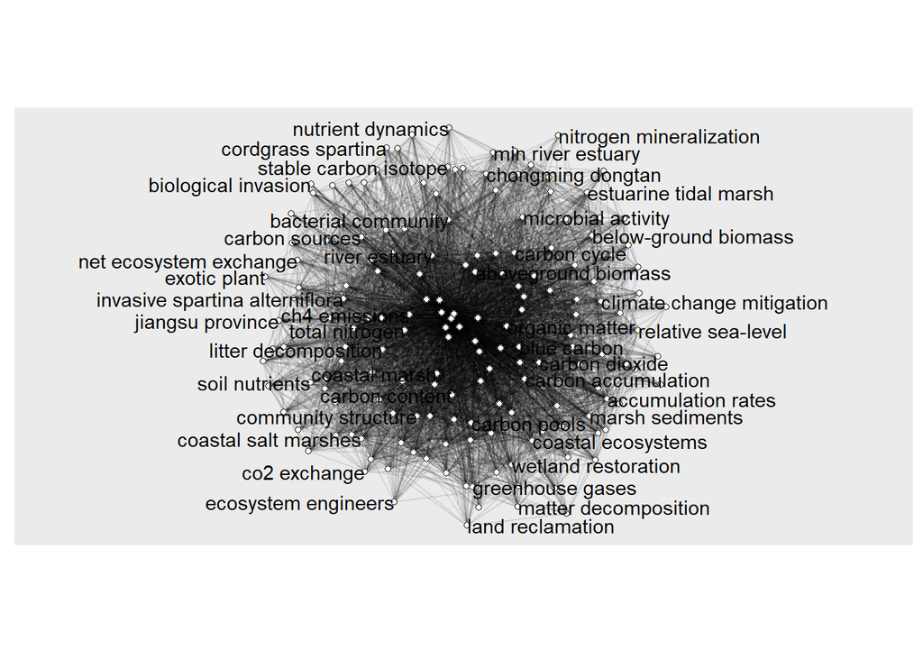

```r
ggraph(g, layout="stress") + #layout draws terms closely linked close together
  coord_fixed() +
  expand_limits(x=c(-3, 3)) +
  geom_edge_link(aes(alpha=weight)) + #darker lines linking terms that appear in more articles together
  geom_node_point(shape="circle filled", fill="white") +
  geom_node_text(aes(label=name), hjust="outward",  check_overlap=TRUE) + #including only an arbirary subset to visualiwze
  guides(edge_alpha=FALSE)
```

### Pruning

Using the network, we can calculate the strength of each term within the network, i.e. the number of terms that it appears with.

```r
salt_marsh_strengths_raw <- strength(g)

salt_marsh_strengths <- data.frame( # creating a dataframe with the names of the terms and the strength of each term
  term=names(salt_marsh_strengths_raw),
  strength=salt_marsh_strengths_raw,
  row.names=NULL)

term_strengths <- salt_marsh_strengths %>%
  mutate(rank=rank(strength, ties.method="min")) %>%
  dplyr::arrange(desc(strength))

term_strengths
```

```
##                                      term strength rank
## 1                          organic carbon     1789  172
## 2                              salt marsh     1510  171
## 3                     soil organic carbon     1432  170
## 4                             soil carbon     1301  169
## 5                         coastal wetland     1116  168
## 6                            salt marshes     1054  167
## 7                   spartina alterniflora     1004  166
## 8                        coastal wetlands      907  165
## 9                          climate change      649  164
## 10                           carbon stock      630  163
## 11                   phragmites australis      577  162
## 12                   carbon sequestration      558  161
## 13                  alterniflora invasion      550  160
## 14                            blue carbon      537  159
```

[output cut: 158 more lines]

The **strongest** terms are near the top of the list. We want to remove the terms that only rarely occur together with others. We can first visualize the node strength of the terms:

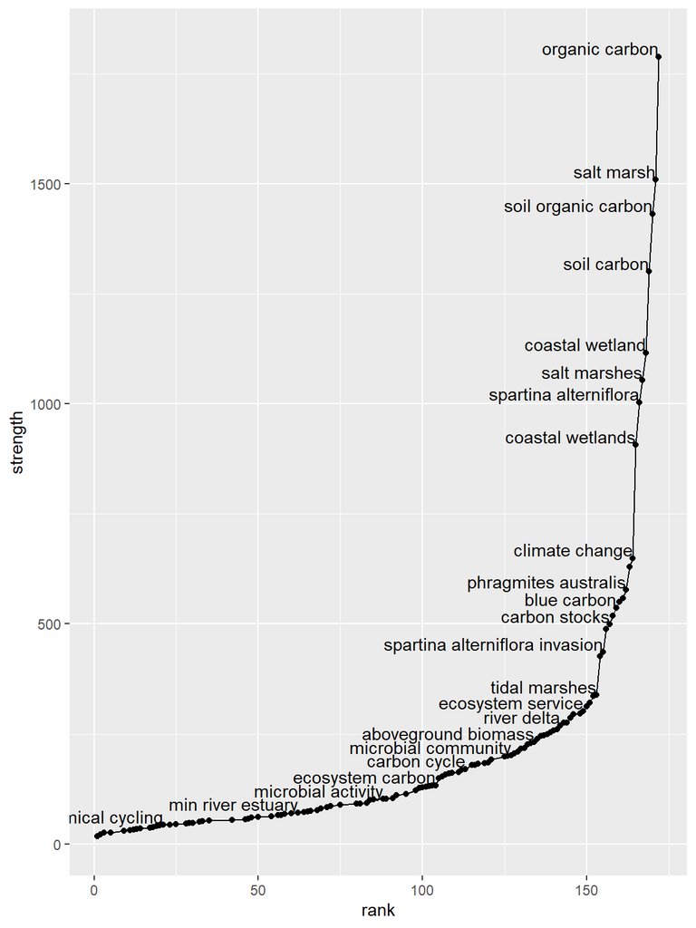

```r
cutoff_fig <- ggplot(term_strengths, aes(x=rank, y=strength, label=term)) +
  geom_line() +
  geom_point() +
  geom_text(data=filter(term_strengths, rank>5), hjust="right", nudge_y=20, check_overlap=TRUE)

cutoff_fig
```

#### Cutting off

We want to keep the terms with large node strengths. We want to find a cutoff to choose to retain a certain proportion of the total strenght of the search terms (i.e. 80%). Note: this percentage can be discussed.

```r
cutoff_cumul <- find_cutoff(g, method="cumulative", percent=0.8)
cutoff_cumul
```

```
## [1] 131
```

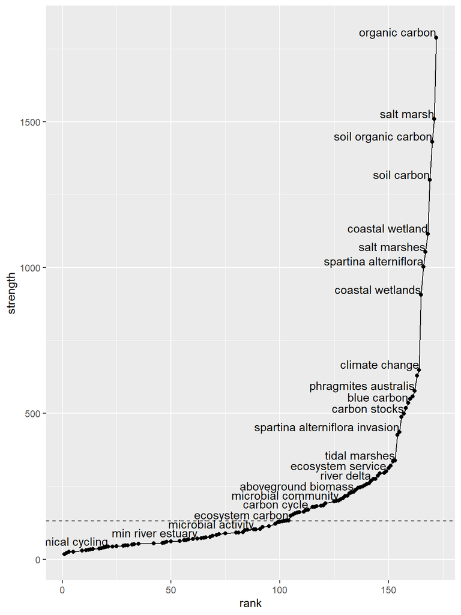

```r
cutoff_fig +
  geom_hline(yintercept=cutoff_cumul, linetype="dashed")
```

```r
reduced_terms <- reduce_graph(g, cutoff_cumul)

reduced_keywords <- get_keywords(reduced_terms)

#to extract the numbered row
keywords_table <- cbind((1:length(reduced_keywords)), reduced_keywords)
keywords_table
```

```
##            reduced_keywords
##  [1,] "1"  "aboveground biomass"
##  [2,] "2"  "accumulation rates"
##  [3,] "3"  "blue carbon"
##  [4,] "4"  "carbon accumulation"
##  [5,] "5"  "carbon cycle"
##  [6,] "6"  "carbon dioxide"
##  [7,] "7"  "carbon sequestration"
##  [8,] "8"  "carbon stock"
##  [9,] "9"  "carbon stocks"
## [10,] "10" "carbon storage"
## [11,] "11" "ch4 emissions"
## [12,] "12" "climate change"
## [13,] "13" "climate change mitigation"
## [14,] "14" "coastal ecosystems"
```

[output cut: 57 more lines]

## Grouping

We need to group our terms manually, either by exporting these terms to a csv, or by placing them into separate vectors.

From this list of terms, we can see that a certain species presence or invasions occur frequently in papers on soil carbon in tidal salt marshes (i.e. *spartina alterniflora, phragmites australis*). While this is an interesting observation, the presence or absence of these species is not part of our broader research question.

We removed any terms that were not specific to tidal salt marsh literature (i.e. coastland wetland, tidal wetland), as it would target papers on mangroves.

```r
grouped_terms <-list(
  carbon_related = reduced_keywords[c(3:10, 30, 31, 40:43, 58:60)],
  marsh_related =reduced_keywords[c(15:17, 36, 37, 48:50, 61, 65, 66)]
)

grouped_terms
```

```
## $carbon_related
##  [1] "blue carbon"          "carbon accumulation"
##  [3] "carbon cycle"         "carbon dioxide"
##  [5] "carbon sequestration" "carbon stock"
##  [7] "carbon stocks"        "carbon storage"
##  [9] "organic carbon"       "organic matter"
## [11] "soil carbon"          "soil organic carbon"
## [13] "soil organic matter"  "soil respiration"
## [15] "carbon content"       "carbon dynamics"
## [17] "carbon pools"
##
## $marsh_related
##  [1] "coastal marsh"        "coastal salt marsh"
##  [3] "coastal salt marshes" "salt marsh"
##  [5] "salt marshes"         "tidal marsh"
##  [7] "tidal marshes"        "tidal salt marsh"
##  [9] "coastal marshes"      "marsh ecosystems"
## [11] "marsh soils"
```

## Writing a new search

```r
write_search(
  grouped_terms,
  languages="English",
  exactphrase=TRUE,
  stemming=FALSE,
  closure="left",
  writesearch=TRUE
)
```

```r
cat(read_file("search-inEnglish.txt"))
```

```
\(\("blue carbon" OR "carbon accumulation" OR "carbon cycle" OR "carbon dioxide" OR "carbon sequestration" OR "carbon stock" OR "carbon storage" OR "organic carbon" OR "organic matter" OR "soil carbon" OR "soil organic carbon" OR "soil organic matter" OR "soil respiration" OR "carbon content" OR "ca…
```

**Important note**: the keyword search using litsearchr only looks for keywords of 2 or more words (this was set in the `extract_terms()` funcation as `min_n`). We will thus add one-word terms that are pertinent to us. Here, I will add “**saltmarsh**” as a term, but not “**marsh**” as this will likely bring in too many freshwater ecosystem data. Finally, we will add asterisks to broaden the scope of the terms:

```
("blue carbon" OR "carbon accumulation" OR "carbon cycle" OR "carbon dioxide" OR "carbon sequestration" OR "carbon stock*" OR "carbon stor*" OR "organic carbon" OR "organic matter" OR "soil carbon" OR "soil organic carbon" OR "soil organic matter" OR "soil respiration" OR "carbon content" OR "carbon dynamic*" OR "carbon pool*") AND ("coastal marsh*" OR "coastal salt marsh*" OR "salt marsh*" OR "tidal marsh*" OR "tidal salt marsh*" OR "marsh ecosystem*" OR "marsh soil*" OR "saltmarsh*")
```

### In another language

Using the `get_languages()` function, the topics query a database of non-English language journals compiled from Ulrich (currently only STEM fields are included in the dataset).

```r
head(get_languages(key_topics = c("soil", "carbon", "wetland")))
```

```
##    language count translatable
## 1   Russian    14         TRUE
## 2    Korean     4         TRUE
## 3   Serbian     4         TRUE
## 4 Ukrainian     3         TRUE
## 5   Chinese     2         TRUE
## 6    German     2         TRUE
```

It seems that we should also be searching journals in Russian. The `write_search()` function supports different languages, but to do so I would need a Google Translate API key. I may just translate the search in google translate.

```r
# write_search()
#   grouped_terms,
#   languages="Russian",
#   exactphrase=TRUE,
#   stemming=FALSE,
#   closure="left",
#   writesearch=TRUE
# )
```

## Comparing databases in WOS

In the abstract search, we would like to have include references from more than one bibliographical source (i.e. from Scopus and from web of science, WOS). However, WOS gives the option for ‘All Databases’, which includes the following databases:

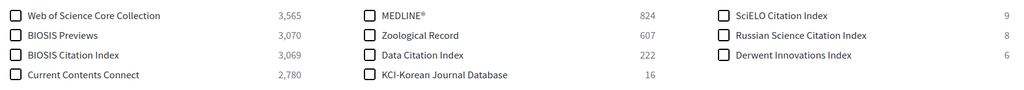

list of databases

We want to see whether adding databases that are not from the core collection, add additional studies that would be relevant to us. To analyze this, we will compare the search results:

```r
wos_all_databases  <-
    import_results(
    directory = "C:/Users/Tania/OneDrive - University of Cambridge/Documents/07_Cam_postdoc/SaltmarshC/reports/01_litsearchr/final_refs/wos_all_databases", #absolute path
    verbose = TRUE
  )
```

```
## Reading file C:/Users/Tania/OneDrive - University of Cambridge/Documents/07_Cam_postdoc/SaltmarshC/reports/01_litsearchr/final_refs/wos_all_databases/wos_all_1.ris ... done
## Reading file C:/Users/Tania/OneDrive - University of Cambridge/Documents/07_Cam_postdoc/SaltmarshC/reports/01_litsearchr/final_refs/wos_all_databases/wos_all_2.ris ... done
## Reading file C:/Users/Tania/OneDrive - University of Cambridge/Documents/07_Cam_postdoc/SaltmarshC/reports/01_litsearchr/final_refs/wos_all_databases/wos_all_3.ris ... done
## Reading file C:/Users/Tania/OneDrive - University of Cambridge/Documents/07_Cam_postdoc/SaltmarshC/reports/01_litsearchr/final_refs/wos_all_databases/wos_all_4.ris ... done
## Reading file C:/Users/Tania/OneDrive - University of Cambridge/Documents/07_Cam_postdoc/SaltmarshC/reports/01_litsearchr/final_refs/wos_all_databases/wos_all_5.ris ... done
```

```r
wos_core_collection  <-
    import_results(
    directory = "C:/Users/Tania/OneDrive - University of Cambridge/Documents/07_Cam_postdoc/SaltmarshC/reports/01_litsearchr/final_refs/wos_core_collection", #absolute path
    verbose = TRUE
  )
```

```
## Reading file C:/Users/Tania/OneDrive - University of Cambridge/Documents/07_Cam_postdoc/SaltmarshC/reports/01_litsearchr/final_refs/wos_core_collection/wos_core_1.ris ... done
## Reading file C:/Users/Tania/OneDrive - University of Cambridge/Documents/07_Cam_postdoc/SaltmarshC/reports/01_litsearchr/final_refs/wos_core_collection/wos_core_2.ris ... done
## Reading file C:/Users/Tania/OneDrive - University of Cambridge/Documents/07_Cam_postdoc/SaltmarshC/reports/01_litsearchr/final_refs/wos_core_collection/wos_core_3.ris ... done
## Reading file C:/Users/Tania/OneDrive - University of Cambridge/Documents/07_Cam_postdoc/SaltmarshC/reports/01_litsearchr/final_refs/wos_core_collection/wos_core_4.ris ... done
```

```r
#adding a column to distinguish the databases
wos_all_databases <- wos_all_databases %>%
  mutate(wos_database = "all") %>%
  relocate(wos_database, .before = date_generated )

wos_core_collection <- wos_core_collection %>%
  mutate(wos_database = "core") %>%
  relocate(wos_database, .before = date_generated )

wos_all <-bind_rows(wos_all_databases, wos_core_collection)

table(wos_all$wos_database)
```

```
##
##  all core
## 4035 3009
```

Now we will remove duplicates by title name.

```r
length(!is.na(wos_all$title)) #all of our journal entries have titles
```

```
## [1] 7044
```

```r
wos_no_duplicates <- remove_duplicates(df = wos_all, field = "title", method = "exact" )

table(wos_no_duplicates$wos_database)
```

```
##
##  all core
## 1008 3006
```

```r
wos_except_core <- wos_no_duplicates %>%
  filter(wos_database == "all") %>%
  droplevels()

# table(wos_except_core$source)
# other_sources <- c(levels(as.factor(wos_except_core$source)))

wos_except_core_ASE <- wos_except_core %>%
  filter(source == "APPLIED SOIL ECOLOGY") %>%
  droplevels()

wos_core_collectio_ASE <- wos_core_collection %>%
  filter(source == "APPLIED SOIL ECOLOGY") %>%
  droplevels()

#comparing title names
c(levels(as.factor(wos_except_core_ASE$title)))
```

```
## [1] "Biological response of a sandy soil treated with biochar derived from a halophyte (Salicornia bigelovii)"
## [2] "Elevated CO2 and nitrogen addition affect the microbial abundance but not the community structure in salt marsh ecosystem"
## [3] "Elevated CO2 causes a change in microbial communities of rhizosphere and bulk soil of salt marsh system"
## [4] "Yak excreta-induced changes in soil microbial communities increased the denitrification rate of marsh soil under warming conditions"
```

```r
c(levels(as.factor(wos_core_collectio_ASE$title)))
```

```
##  [1] "Alterations of bacterial and archaeal communities by freshwater input in coastal wetlands of the Yellow River Delta, China"
##  [2] "Contributions of ant mounds to soil carbon and nitrogen pools in a marsh wetland of Northeastern China"
##  [3] "Effect of tillage and farming management on Collembola in marsh soils"
##  [4] "Effects of waterlogging and salinity increase on CO2 efflux in soil from coastal marshes"
##  [5] "Elevated CO2 and high salinity enhance the abundance of sulfate reducers in a salt marsh ecosystem"
##  [6] "Exotic purple loosestrife invasion of native cattail freshwater wetlands: Effects on organic matter distribution and soil nitrogen cycling"
##  [7] "Impact of Spartina alterniflora invasion on soil bacterial community and associated greenhouse gas emission in the Jiuduansha wetland of China"
##  [8] "Meta-analysis demonstrating that moderate grazing can improve the soil quality across China's grassland ecosystems"
##  [9] "Nitrogen addition differently alters GHGs production and soil microbial community of tidal salt marsh soil depending on the types of halophyte"
## [10] "Nutrients, microbial community structure and functional gene abundance of rhizosphere and bulk soils of halophytes"
## [11] "Seawall construction alters soil carbon and nitrogen dynamics and soil microbial biomass in an invasive Spartina alterniflora salt marsh in eastern China"
## [12] "Soil engineering ants increase CO2 and N2O emissions by affecting mound soil physicochemical characteristics from a marsh soil: A laboratory study"
```

Here, we can see that for the journal Applied Soil Ecology, the core collection detected 12 titles while using all other databases, an additional 4 papers were found.

## Final search terms

1. Is it worthwhile to search the keywords in Russian? This likely depends on salt marsh extent in Russia.
2. Checking the new search

Using the final new search, the following hits came up on 28 Jan 2022:

- 3,009 on Web of Science (core collection only)
- 4,035 on Wed of Science (all databases)
- 2,428 on Scopus

# Using synthesisr

```r
library(litsearchr)
library(synthesisr)
library(tidyr)
library(dplyr)
```

## Import and deduplicate references

```r
wos_final_all  <-
    import_results(
    directory = "C:/Users/Tania/OneDrive - University of Cambridge/Documents/07_Cam_postdoc/SaltmarshC/reports/01_litsearchr/final_refs/wos_all_databases", #absolute path
    verbose = TRUE
  )
```

```
## Reading file C:/Users/Tania/OneDrive - University of Cambridge/Documents/07_Cam_postdoc/SaltmarshC/reports/01_litsearchr/final_refs/wos_all_databases/wos_all_1.ris ... done
## Reading file C:/Users/Tania/OneDrive - University of Cambridge/Documents/07_Cam_postdoc/SaltmarshC/reports/01_litsearchr/final_refs/wos_all_databases/wos_all_2.ris ... done
## Reading file C:/Users/Tania/OneDrive - University of Cambridge/Documents/07_Cam_postdoc/SaltmarshC/reports/01_litsearchr/final_refs/wos_all_databases/wos_all_3.ris ... done
## Reading file C:/Users/Tania/OneDrive - University of Cambridge/Documents/07_Cam_postdoc/SaltmarshC/reports/01_litsearchr/final_refs/wos_all_databases/wos_all_4.ris ... done
## Reading file C:/Users/Tania/OneDrive - University of Cambridge/Documents/07_Cam_postdoc/SaltmarshC/reports/01_litsearchr/final_refs/wos_all_databases/wos_all_5.ris ... done
```

```r
scopus_final  <-
    import_results(
    directory = "C:/Users/Tania/OneDrive - University of Cambridge/Documents/07_Cam_postdoc/SaltmarshC/reports/01_litsearchr/final_refs/scopus", #absolute path
    verbose = TRUE
  )
```

```
## Reading file C:/Users/Tania/OneDrive - University of Cambridge/Documents/07_Cam_postdoc/SaltmarshC/reports/01_litsearchr/final_refs/scopus/scopus_1.ris ... done
## Reading file C:/Users/Tania/OneDrive - University of Cambridge/Documents/07_Cam_postdoc/SaltmarshC/reports/01_litsearchr/final_refs/scopus/scopus_2.ris ... done
```

```r
refs_combined <- bind_rows(wos_final_all, scopus_final)
```

```r
# run deduplication
dups <- find_duplicates(
  refs_combined$title,
  method = "string_osa",
  rm_punctuation = TRUE,
  to_lower = TRUE)

final_refs <- extract_unique_references(refs_combined, matches = dups)
```

## Format the final reference table

```r
#clean column and author names
final_refs <- clean_df(final_refs)

#remove unnecessary columns

final_refs <- final_refs %>%
  dplyr::select(author:doi, publisher, M3, PI, database,
                document_type, n_duplicates) %>%
  rename(scopus_doc_type = document_type,
         wos_doc_type = M3,
         publish_location = PI)

final_refs$database <- final_refs$database %>%
  replace_na('WOS') #adding WOS
```

```r
write_refs(final_refs, format = "ris", file = TRUE)
```

## Check by comparison

We will double-check our literature search using the following two sources:

### Alongi 2020 JSME

```r
alongi_refs  <-
    import_results(
    directory = "C:/Users/Tania/OneDrive - University of Cambridge/Documents/07_Cam_postdoc/SaltmarshC/reports/01_litsearchr/alongi_2020", #absolute path
    # file = "alongi_refs.ris",
    verbose = TRUE
  )
```

```
## Reading file C:/Users/Tania/OneDrive - University of Cambridge/Documents/07_Cam_postdoc/SaltmarshC/reports/01_litsearchr/alongi_2020/alongi_refs.ris ... done
```

```r
alongi_refs <- alongi_refs %>%
  dplyr::select(author:end_page, source_type)
```

```r
compare_alongi <- bind_rows(final_refs, alongi_refs)

dups_alongi <- find_duplicates(
  compare_alongi$title,
  method = "string_osa",
  rm_punctuation = TRUE,
  to_lower = TRUE)

dups_alongi_review <- review_duplicates(compare_alongi$title,
                                        matches = dups_alongi)
dups_alongi_review
```

```r
compare_alongi$database <- compare_alongi$database %>%
  replace_na('Alongi') #adding WOS

table(compare_alongi$database)


deduplicate_alongi <- extract_unique_references(compare_alongi,
                                                 matches = dups_alongi)

table(deduplicate_alongi$database)

alongi_not_found <- deduplicate_alongi %>%
  filter(database == "Alongi")
```

Here are the 8 papers not found :

[1] “Invasive Spartina anglica Greatly Alters the Rates and Pathways of Organic Carbon Oxidation and Associated Microbial Communities in an Intertidal Wetland of the Han River Estuary, Yellow Sea” 2020 - this was actually found in the search

[2] “Cordgrass biomass in coastal marshes” 2010 - this only includes aboveground and belowground biomass of cordgrass, so it is normal that it is not in our search

[3] “Mapping coastal wetland biomass from high resolution unmanned aerial vehicle (UAV) imagery” 2019  
- this only includes aboveground biomass of cordgrass, so it is normal that it is not in our search

[4] “Blue carbon’ and nutrient stocks of salt marshes at a temperate coastal lagoon (Ria de Aveiro)” 2017 - this was in our search, there was just the first apostrophe missing

[5] “Belowground biomass of Phragmites australis in coastal marshes” 2012  
- this paper only includes root biomass, so it is normal that it is not in our search

[6] “Carbon stocks and accumulation rates in salt marshes of the Pacific coast of Canada” 2018  
- the revision of this paper was not accepted in Biogeosciences. It is now under revies as “Quantification of Blue Carbon in Salt Marshes of the Pacific Coast of Canada”, but **how can we extract this kind of data?** Should we wait until it has been officially published?

[7] “Coastal blue carbon assessment of mangroves, salt marshes, and salt barrens in Tampa” NA year - 2018 - this was in our search, but as “…Tampa Bay, Florida, USA”

[8] “Carbon storage increases with site age as created salt marshes transition to mangrove forests in Tampa” NA year - 2020 - this was in our search, but as “…Tampa Bay, Florida, USA”

We conclude that our search terms correctly extract the available information on soil carbon, that was used in Alongi 2020 estimates of soil carbon in tidal salt marshes.

### Smithsonian coastal carbon

```r
ccrcn_refs  <-
    import_results(
    directory = "C:/Users/Tania/OneDrive - University of Cambridge/Documents/07_Cam_postdoc/SaltmarshC/reports/01_litsearchr/CCRCN", #absolute path
    verbose = TRUE
  )
```

```r
compare_ccrcn <- bind_rows(final_refs, ccrcn_refs)

dups_ccrcn <- find_duplicates(
  compare_ccrcn$title,
  method = "string_osa",
  rm_punctuation = TRUE,
  to_lower = TRUE)

dups_ccrcn_review <- review_duplicates(compare_ccrcn$title,
                                        matches = dups_ccrcn)
dups_ccrcn_review
```

```r
compare_ccrcn$database <- compare_ccrcn$database %>%
  replace_na('ccrcn') #adding CCRCN

table(compare_ccrcn$database)


deduplicate_ccrcn <- extract_unique_references(compare_ccrcn,
                                                 matches = dups_ccrcn)

table(deduplicate_ccrcn$database)

ccrcn_not_found <- deduplicate_ccrcn %>%
  filter(database == "ccrcn")

ccrcn_not_found

levels(as.factor(ccrcn_not_found$publisher))
```

First, it seems like half of the references not found were from the Smithsonian directly.

```r
ccrcn_not_found_smith <- ccrcn_not_found %>%
  filter(publisher == "The Smithsonian Institution" |
           publisher == "Smithsonian Research Online")
nrow(ccrcn_not_found_smith)
```

```
## [1] 16
```

```r
final_refs_smith <- final_refs %>%
  filter(publisher == "THE SMITHSONIAN INSTITUTION" |
           publisher == "SMITHSONIAN RESEARCH ONLINE")

final_refs_smith
```

```
##  [1] author           year             title
##  [4] source           volume           issue
##  [7] start_page       end_page         abstract
## [10] doi              publisher        wos_doc_type
## [13] publish_location database         scopus_doc_type
## [16] n_duplicates
## <0 rows> (or 0-length row.names)
```

There are thus 16 references directly published by the Smithsonium Institute that were not caught in our search.

We will now look through the other 12 references not caught by our search.

```r
ccrcn_not_found_res <- ccrcn_not_found %>%
  filter(publisher != "The Smithsonian Institution") %>%
  filter(publisher != "Smithsonian Research Online")

list(ccrcn_not_found_res$title)
```

[1] “Geomorphic and ecological effects of Hurricanes Katrina and Rita on coastal Louisiana marsh communities” - this was in our search

[2] “Sediment Deposition and Accretion in a Mid-Atlantic (U.S.A.) Tidal Freshwater Marsh”  
- this was in our search (U.S.A. as USA)

[3] “Atmospheric Deposition of Metals to Coastal Waters (Long Island Sound, New York U.S.A.): Evidence from Saltmarsh Deposits” - THIS IS MISSING. Nowhere in the abstract is carbon written, there is only a graph with “organic matter”

[4] “Peat Accretion Histories During the Past 6,000~Years in Marshes of the Sacramento{\textendash}San Joaquin Delta, {CA}, {USA”  
- this was in our search

[5] “Reconstructing Common Era relative sea-level change on the Gulf Coast of Florida”  
- THIS IS MISSING. Irrelevant

[6] “PIE LTER high marsh sediment chemistry and activity measurements, Nelson Island Creek marsh, Rowley, MA”  
- THIS IS MISSING. Can’t find on google scholar

[7] “Use of lead isotopes for developing chronologies in recent salt-marsh sediments”  
- THIS IS MISSING. **We should add salt-marsh* to the key terms**. Nowhere in the abstract is carbon written, there is only a graph with “organic matter”

[8] “Influence of wind-driven inundation and coastal geomorphology on sedimentation in two microtidal marshes, Pamlico River Estuary, NC”  
- THIS IS MISSING. There is interesting organic matter data, but no indication of this in the abstract. also, they refer to marshes instead of tidal or salt marshes

[9] “Carbon storage in US wetlands” - THIS IS MISSING. This is a review - maybe it’s ok that it’s not included in our search? Would be interesting to read the paper Nahlik, A. M., & Fennessy, M. (2016). Carbon storage in US wetlands. Nature Communications, 7(1), 1-9.

[10] “Vegetation, soil, and landscape data”  
- THIS IS MISSING (US Survey). Not found on google scholar.

[11] “Vertical Accretion Rates and Heavy Metal Chronologies in Wetland Sediments of the Tijuana Estuary”  
- THIS IS MISSING. This is in a salt marsh and has a table with organic matter content. But not indicated in the abstract

[12] “Biogeochemical processes in an urban, restored wetland of San Francisco Bay, California, 2007-2009$\\mathsemicolon$ methods and data for plant, sediment and water parameters” - THIS IS MISSING. This has supplementary data with organic carbon content that would be useful to include. In the abstract they mention carbon, **should we include “carbon*” as a search term?**

**Maybe we should include the term accretion rate* in our search?** This would be to get these extra data files. As for the data from the Smithsonian Institute, since the data is systematically not picked up with web of science and scopus with our search terms, we can include this data as external data to our search. We should just decide whether to actively include more search terms in our final search, such as “carbon” or “accretian rate”.

## Exploring the final reference list

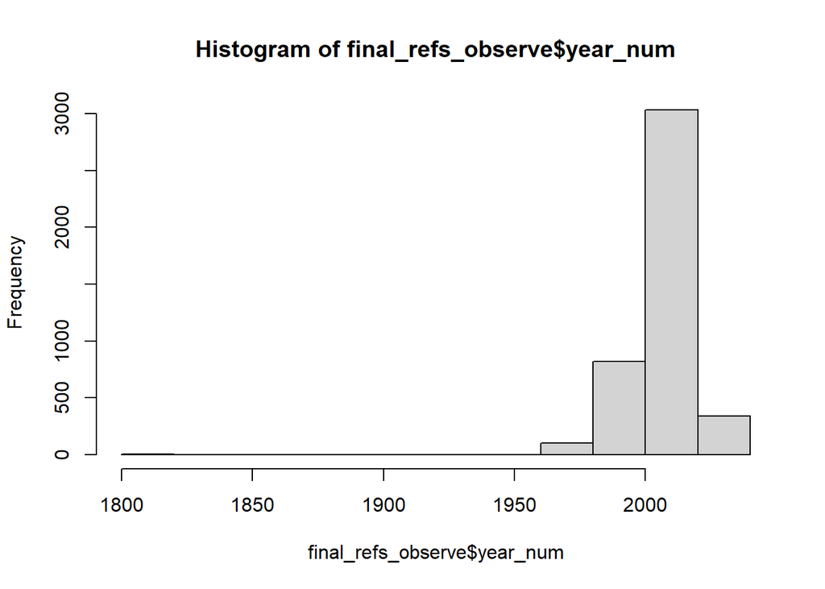

```r
final_refs_observe <- final_refs %>%
  mutate(year_num = as.numeric(year)) %>%
  mutate_if(is.character, as.factor)

library(ggplot2)

hist(final_refs_observe$year_num) # too spread out
```

```r
summary(final_refs_observe$year_num)
```

```
##    Min. 1st Qu.  Median    Mean 3rd Qu.    Max.    NA's
##    1800    2003    2013    2009    2018    2022      12
```

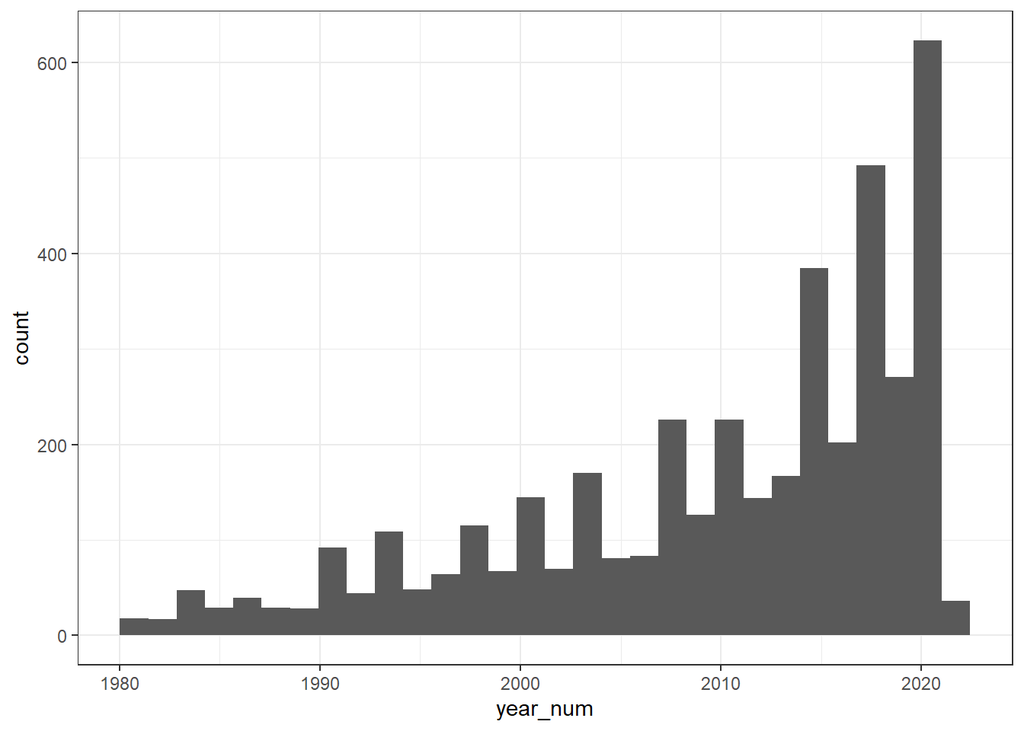

```r
p <- final_refs_observe %>%
  filter(year_num > 1980) %>%
  ggplot(aes(x = year_num))+
  geom_histogram()+
  theme_bw()
p
```

```r
table(final_refs_observe$wos_doc_type)
```

```
##
##                                                                   Article
##                                                                      3282
##                                                  Article and Book Chapter
##                                                                        50
##                                                    Article and Data Paper
##                                                                         3
##                                                  Article and Early Access
##                                                                        18
##                                                 Article and Meeting paper
##                                                                         1
##                                             Article and Proceedings Paper
##                                                                       101
##                                                                      Book
##                                                                         4
##                                                              Book Chapter
##                                                                         1
##                                                      Book Chapter Meeting
##                                                                         2
##                                                              Book Meeting
##                                                                         5
##                                                 Book Meeting Book Chapter
##                                                                         2
##                                                                Correction
##                                                                         2
##                                                                  Data set
##                                                                       166
##                                                                Data study
##                                                                        13
##                                                        Editorial Material
##                                                                        13
##                                       Editorial Material and Book Chapter
##                                                                         3
## English Abstract and Journal Article and Research Support, Non-U.S. Gov't
##                                                                         1
##                                                           Journal Article
##                                                                        11
##                      Journal Article and Research Support, Non-U.S. Gov't
##                                                                         2
##                                                Journal Article and Review
##                                                                         1
##                                                                   Meeting
##                                                                        46
##                                                          Meeting Abstract
##                                                                        17
##                                                                      Note
##                                                                        11
##                                                         Proceedings Paper
##                                                                        47
##                                                          research-article
##                                                                        11
##                                                                    Review
##                                                                       118
##                                                   Review and Book Chapter
##                                                                         9
##                                                   Review and Early Access
##                                                                         1
##                                                                  Software
##                                                                         2
```

```r
table(final_refs_observe$scopus_doc_type)
```

```
##
##           Article  Article in Press              Book
##              2058                 1                 5
##      Book Chapter  Conference Paper Conference Review
##                46                69                 4
##        Data Paper           Erratum            Letter
##                 1                 2                 1
##              Note         Retracted            Review
##                 6                 2                74
##      Short Survey
##                 1
```

## References

Grames, Eliza M., Andrew N. Stillman, Morgan W. Tingley, and Chris S. Elphick. 2019. “An Automated Approach to Identifying Search Terms for Systematic Reviews Using Keyword Co-Occurrence Networks.” Edited by Robert Freckleton. *Methods in Ecology and Evolution* 10 (10): 1645–54. https://doi.org/10.1111/2041-210X.13268.